# Использование протокола STP. Агрегирование каналов

Лабораторная работа №9

Гафоров Нурмухаммад

Российский университет дружбы народов, Москва, Россия

06.04.2026

# Цель работы

## Цель

Изучение работы протокола STP и Rapid PVST+  
исследование отказоустойчивости сети  
настройка агрегирования каналов EtherChannel

# Ход выполнения

## Исходная топология

- Изменено соединение между коммутаторами
- Настроены trunk-интерфейсы
- Добавлен резервный путь передачи данных

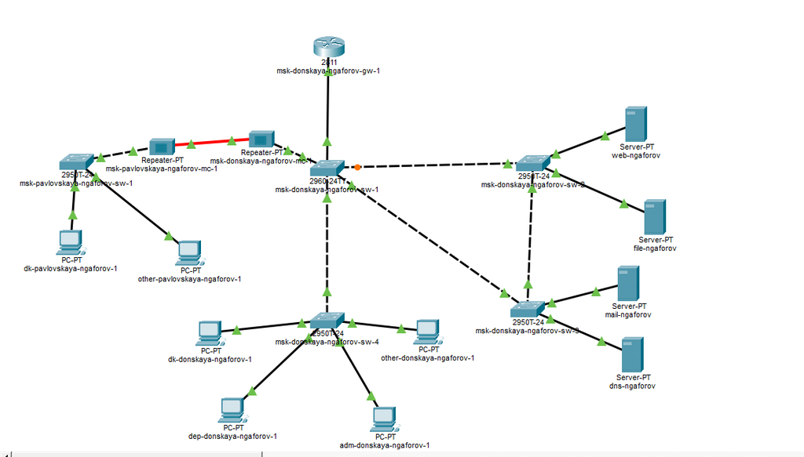

Топология сети

## Проверка связности

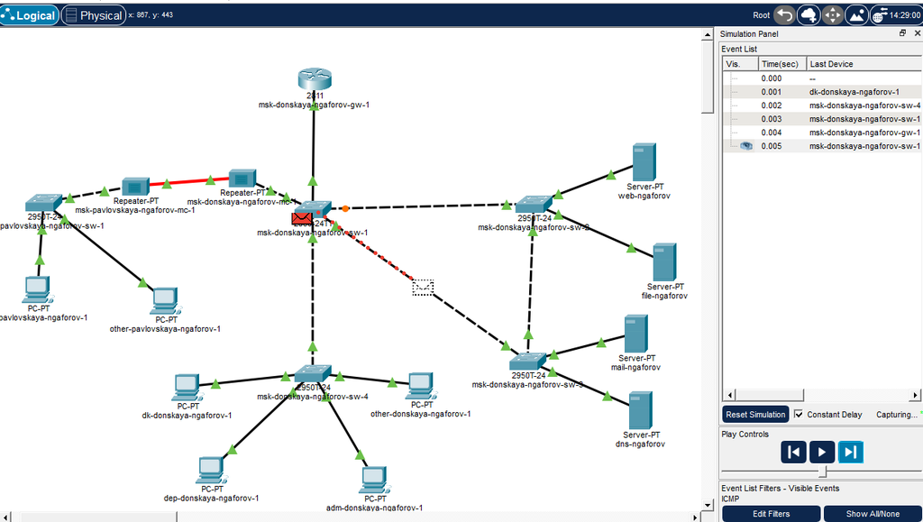

Передача ICMP

## Работа STP

- Один из путей заблокирован
- Предотвращение петель
- Формирование дерева сети

[figure not shown]

Работа STP

## Анализ STP

- Использована команда show spanning-tree vlan 3
- Определён корневой коммутатор
- Выявлены роли портов

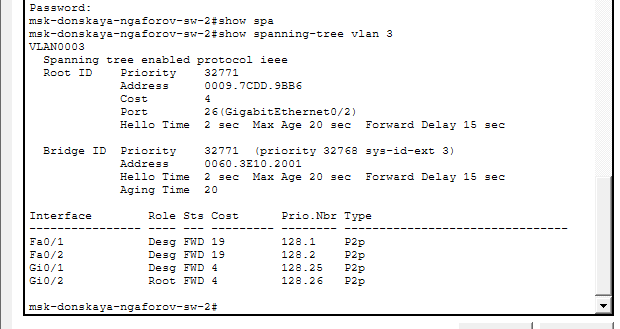

Состояние STP

## Назначение Root Bridge

- Настроен sw-1 как корневой
- Выполнена команда root primary
- Произошёл пересчёт дерева

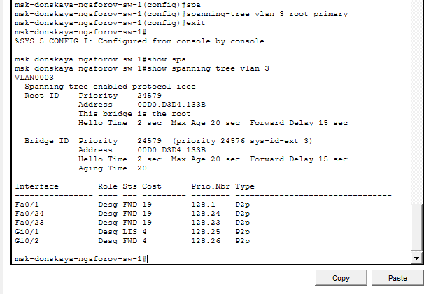

Root Bridge

## Изменение маршрутов

- Путь к web через sw-2
- Путь к mail через sw-3
- Балансировка нагрузки

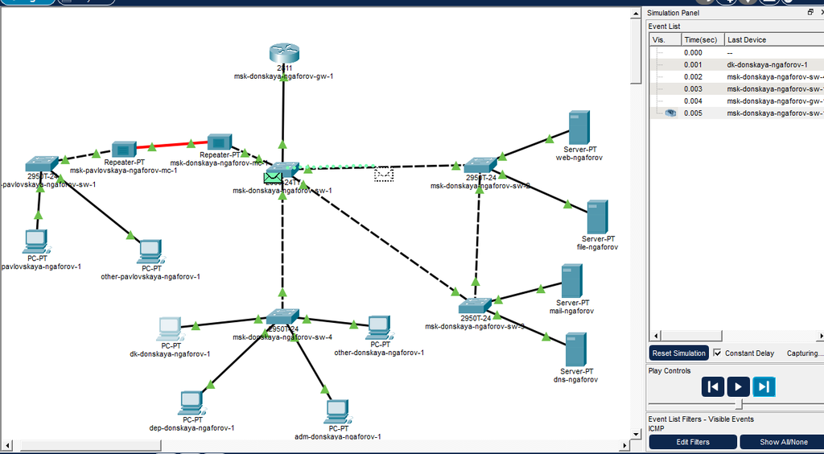

Новые маршруты

## PortFast

- Включён на серверных портах
- Ускорен переход в Forwarding
- Исключены задержки подключения

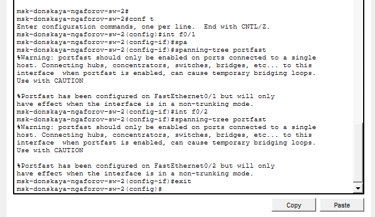

PortFast

## Отказоустойчивость STP

- Выполнен ping с большим числом пакетов
- Разорван канал (shutdown)
- Зафиксированы потери пакетов

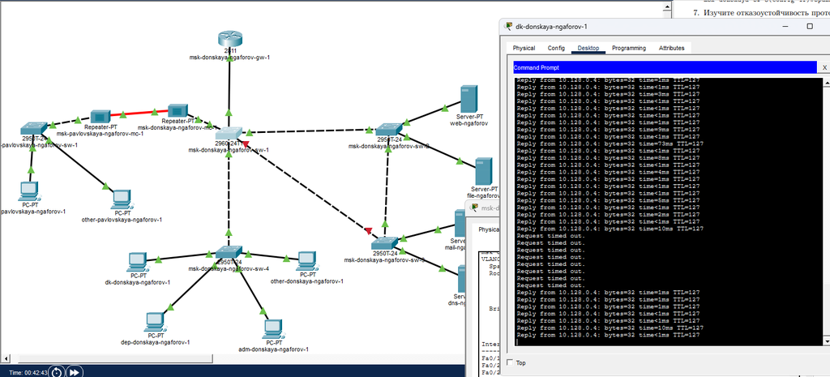

Потери пакетов

## Восстановление STP

- Длительное восстановление
- Переход через Listening и Learning
- Восстановление связи

[figure not shown]

Восстановление

## Rapid PVST+

- Все коммутаторы переведены в rapid-pvst
- Ускорена сходимость сети

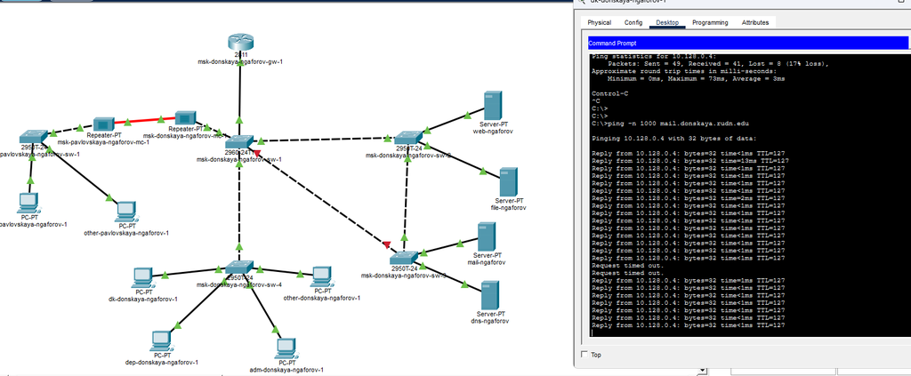

Rapid PVST+

## Проверка Rapid PVST+

- Снова выполнен разрыв канала
- Потери пакетов уменьшились
- Быстрое восстановление

[figure not shown]

Работа Rapid STP

## Настройка EtherChannel

- Интерфейсы добавлены в channel-group
- Настроен trunk
- Получены предупреждения несовместимости

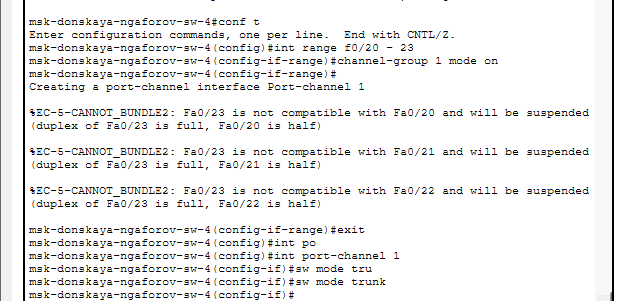

Настройка EtherChannel

## Проверка EtherChannel

- Канал успешно создан
- Связность без потерь
- Повышена пропускная способность

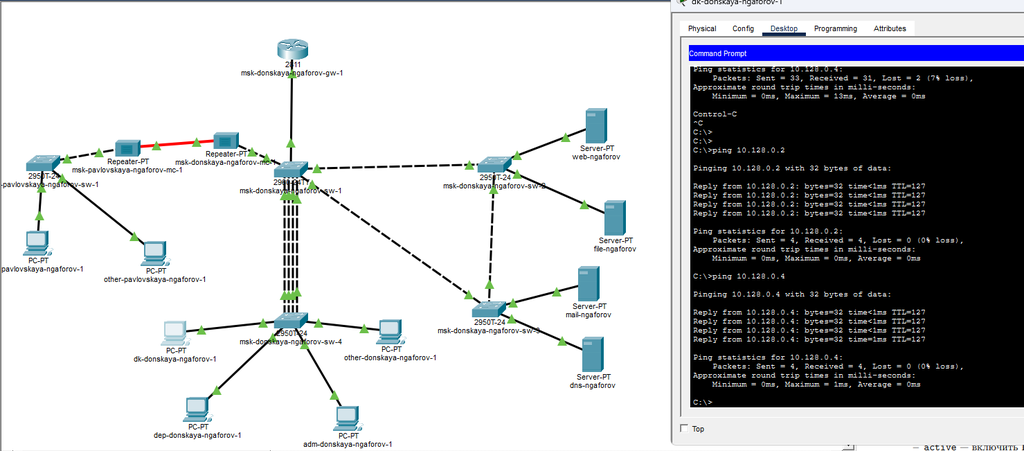

Работа EtherChannel

# Итог

## Вывод

- Изучена работа STP и Rapid PVST+
- Проанализирована отказоустойчивость
- Выполнено агрегирование каналов
- Повышена надёжность и производительность сети